# Visualización: gráficos con ggplot2

#### Colores

Se poco de colores, pero claro si quieres cambiar la apariencia de los gráficos, has de saber los colores de R, así que:

- [Aquí](http://sape.inf.usi.ch/quick-reference/ggplot2/colour) tienes una guía para elegir color. Si solo quieres ver la lista de nombres de los colores en R ejecuta: `aa <- as.data.frame(colours())`
- Si sabes el nombre del color que quieres, [aquí](https://pkg.garrickadenbuie.com/r-colors-css/), podrás buscarlo y ver su color y su codificación en RGB y Hex.
- También es interesante el paquete [paleteer](https://github.com/EmilHvitfeldt/paletteer) que agrupa un conjunto amplio de paletas de colores para usar en R.

#### XKCD theme

Por último, no sé si conocéis el [webcomic XKCD](https://xkcd.com/). Pues en R también hay un paquete y un theme para hacer gráficos al estilo XKCD. Es el [paquete xkcd](https://cran.r-project.org/web/packages/xkcd/index.html) cuyo autor es Emilio Torres-Manzanera de la Universidad de Oviedo. [Aquí](http://xkcd.r-forge.r-project.org/) podéis ver algunos gráficos hechos con este estilo en R.

Intenté hacer un gráfico con su theme, pero desafortunadamente no me salió; pero justo al día siguiente vi [este tweet](https://twitter.com/_Gil_Henriques/status/1166440262773567488?s=09)[^7] que hace algo parecido con datos de los Simpsons y [su código](https://github.com/GilHenriques/TidyTuesdays/blob/master/2019-08-27%20Simpsons%20guest%20stars/simpsons.R) sí me ha funcionado, además simula/construye el estilo XKCD desde cero.

Además, después vi que Evangelyne Reinolds hizo [esta maravilla](https://evamaerey.github.io/tidytuesday_walk_through/simpsons.html#1). Lo haremos en clase?! En [este post](https://blog.revolutionanalytics.com/2018/09/curve-fitting.html) puedes encontrar el código para reproducir una de las historias o viñetas de XKCD.

### 3.3 Small multiples o Facetting

El sistema gráfico de `ggplot2` incorpora una técnica especial llamada “faceting” que permite dividir un gráfico en múltiples gráficos. Cada uno de esos múltiples gráficos se realiza sólo para las observaciones de una de los valores de una variable categórica (o factor) incluido en el conjunto de datos. Es más fácil hacerlo que explicarlo/escribirlo.

Por ejemplo, en `iris` tenemos la variable `Species`, que es categórica. Lo que se hace con el “facetting” es dividir el dataset en grupos y hacer el mismo gráfico para cada uno de los grupos. Los grupos se van a definir en función de los valores de la variable Species. Recuerda que hay tres tipos o especies de lirios.

Para hacer un “facetting graph” podemos usar las funciones `facet_wrap()` y `facet_grid()`.

Por ejemplo, con la función `facet_grid()` puedes elegir entre hacer los small multiples por filas o por columnas. Empecemos haciendo un facetting **por columnas**. Además, con `facet_grid()` se pueden usar varias sintaxis, pero la que aparece en la [cheatsheet actual de ggplot2](https://www.rstudio.com/resources/cheatsheets/) y, por tanto, la recomendada es las que ves en la segunda linea:

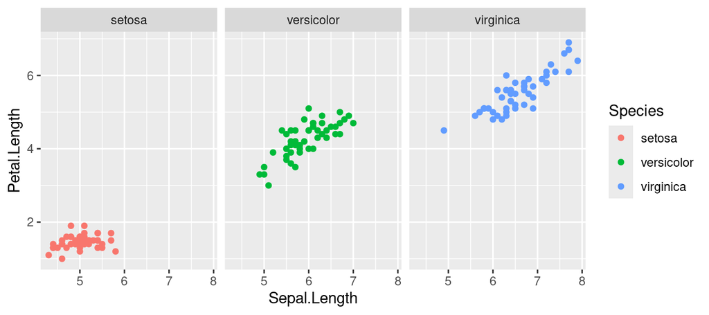

```r
#p + facet_grid( . ~ Species)                # old sintaxis
p + facet_grid(cols = vars(Species))         # gráficos x columnas, separando por valores de 'Species'
```

Ahora por filas:

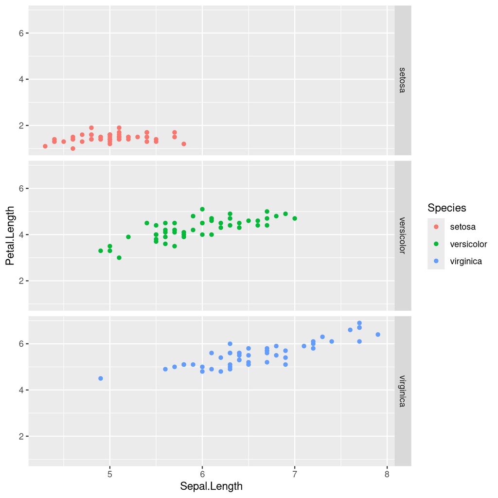

```r
p + facet_grid(rows = vars(Species))         # gráficos x filas
```

También podemos utilizar la función **`facet_wrap()`**. Esta función reparte los small multiples en una rejilla con forma de matriz.

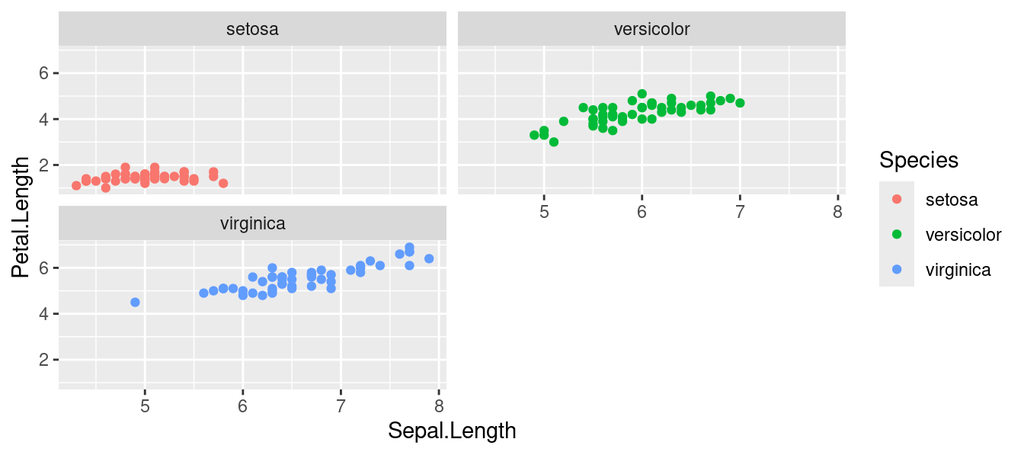

```r
p + facet_wrap(vars(Species), nrow = 2, ncol = 2)        # graf x filas y columnas
```

Si en el dataset hubiesen dos variables categóricas podríamos hacer que una de ellas sirviese para llenar las filas y la otra las columnas.

Como `iris` sólo tiene una variable categórica (Species) vamos a discretizar una de las variables continuas. Por ejemplo la anchura del pétalo, crearemos una nueva variable dividiendo las observaciones de `Petal.Width` en 2 categorías, por encima y por debajo de la media de su media. Además lo vamos a hacer con R-base y con `dplyr::ntile()`. Seguro que hay mejores formas, [por ejemplo](https://www.rdocumentation.org/packages/arules/versions/1.6-3/topics/discretize)

Con `dplyr::ntile()`

```r
iris <- iris %>% mutate(new_variable = ntile(Petal.Width, 2))
```

Con R-base y la función `cut()`:

```r
iris <- iris
iris$new_variable <- cut(iris$Petal.Width,
                   breaks = c(-Inf, mean(iris$Petal.Width), Inf),
                   labels = c("debajo-media", "arriba-media"))
```

Ahora ya tenemos dos variable discreta y podemos hacer que `facet_grid()` utilice una variable para llenar filas y otra para columnas. Se puede especificar de dos maneras

```r
ggplot(iris) + geom_point( aes(Sepal.Length, Petal.Length, color = Species)) +
facet_grid(rows = vars(new_variable), cols = vars(Species))        # graf x filas y columnas
```

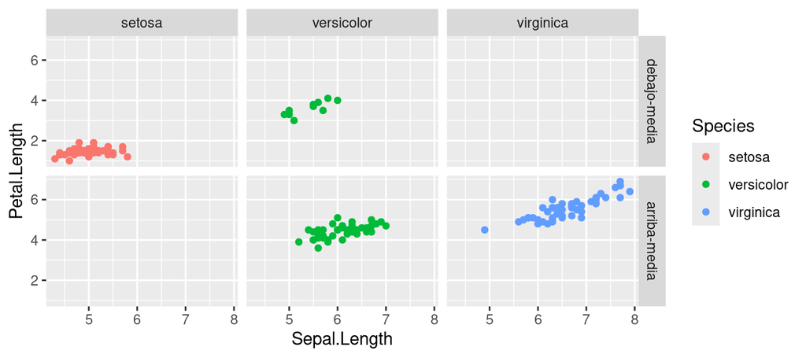

```r
ggplot(iris) + geom_point( aes(Sepal.Length, Petal.Length, color = Species)) +
facet_grid(new_variable ~ Species)
```

Como vemos, los lirios de la clase setosa siempre tiene el ancho de su pétalo por debajo de la media, y los virginica siempre están por encima de la media.

#### Ejes de los small multiples

Podemos ajustar las escalas de los ejes para que sean comunes para cada small multiple (la opción por defecto) o dejar que las escalas de cada gráfico varíen en función del rango de los datos representados:

```r
p + facet_grid(rows = vars(Species))    #- escalas comunes
p + facet_grid(rows = vars(Species), scales = "free")   #- las escalas de cada small pueden variar
p + facet_grid(rows = vars(Species), scales = "free_y") #- solo dejamos libre/variar la escala del eje y
```

Solo muestro el resultado de la segunda expresión:

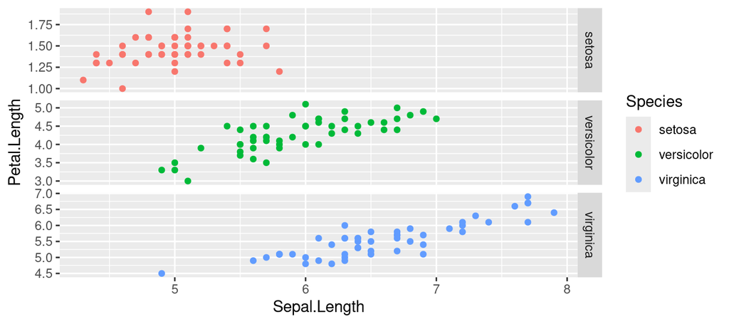

**Un truquito:** el argumento `margin` en `ggplot2::facet_grid()` añade margenes a los small multiples facilitando la visualización. Además añade un nuevo small con todas las observaciones.

> TIL the `margin` argument in [#ggplot2](https://twitter.com/hashtag/ggplot2?src=hash&ref_src=twsrc%5Etfw) `facet_grid()` for adding margins to your plots. It makes comparison easier across panels. [#rstats](https://twitter.com/hashtag/rstats?src=hash&ref_src=twsrc%5Etfw) [pic.twitter.com/Vv0xclsqsT](https://t.co/Vv0xclsqsT)

> — We are R-Ladies (@WeAreRLadies) [April 30, 2019](https://twitter.com/WeAreRLadies/status/1123109094422921216?ref_src=twsrc%5Etfw)

Puedes probarlo tú mismo corriendo lo siguiente:

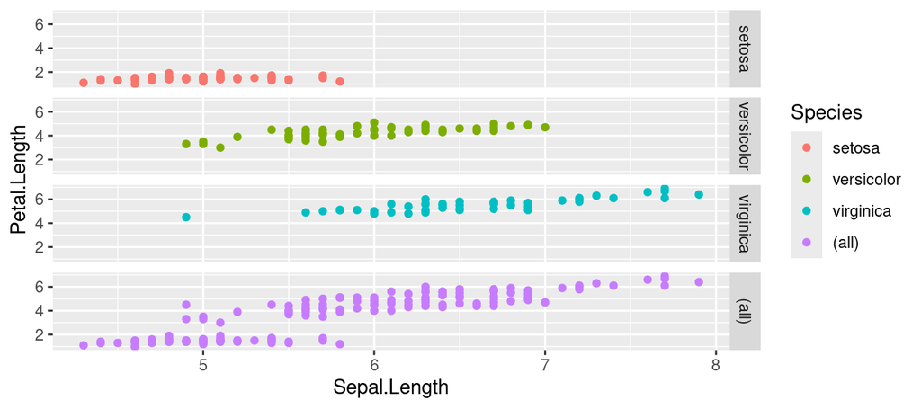

```r
p + facet_grid(rows = vars(Species),  margins = TRUE)
```

Otro truco, esta vez avanzado: Un [gist](https://gist.github.com/padpadpadpad/dc1f4520e4f9530b2c70fed0e4a425e9) para poner labels a los smalls multiples.

### 3.4 Anotaciones

> Annotations are a special type of layer that don’t inherit global settings from the plot. They are used to add fixed reference data to plots.

Las anotaciones en los gráficos permiten resaltar algún fenómeno u observación de interés, y son importantes a la hora de contar historias (storytelling) con los gráficos y visualizaciones.

En el entorno `ggplot` podemos hacer anotaciones en nuestro gráficos de varias maneras, por ejemplo con `annotate()`. Aunque conceptualmente, como señala Hadley, las anotaciones son metadatos, desde el punto de vista práctico se usan los mismas funciones o geoms para manipularlos.

También existen algunas funciones auxiliares en ggplot2 y en paquetes específicos para hacer anotaciones en gráficos ggplot. Por ejemplo, cuando se hacen anotaciones en un gráfico de puntos es fácil que las anotaciones caigan unas encima de otras, el paquete [ggrepel](https://buff.ly/2HXErxL) permite aliviar este problema.

Utilicemos la función `annotate()`. Por ejemplo, el siguiente chunk hace algunas anotaciones sin mucho sentido pero fáciles de entender:

Por ejemplo, el siguiente chunk usa `annotate()` para hacer algunas anotaciones sin mucho sentido, pero fáciles de entender:

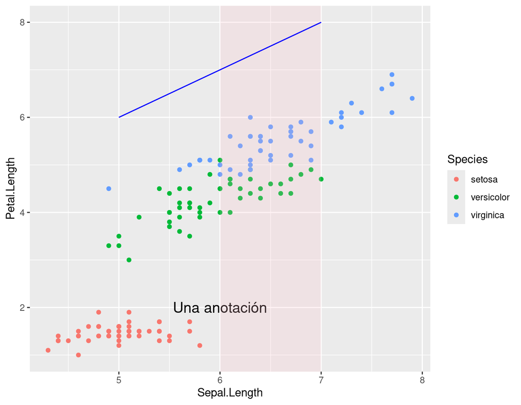

```r
p + annotate(geom = "text", x = 6, y = 2, label = "Una anotación", size = 5) +
    annotate("rect", xmin = 6, xmax = 7,ymin = -Inf, ymax = Inf, alpha = 0.2, fill = "pink") +
    annotate("segment", x = 5, xend = 7, y = 6, yend = 8, colour = "blue")
```

#### Anotaciones de texto en las observaciones

Agregar texto a un gráfico es una de las formas más comunes de anotación. Por ejemplo, para señalizar e identificar observaciones anómalas. Sin embargo, como señala Hadley, añadir texto no es fácil por la forma en la que R maneja las fuentes.

La función principal para el etiquetado de gráficos es `geom_text()`. Por ejemplo:

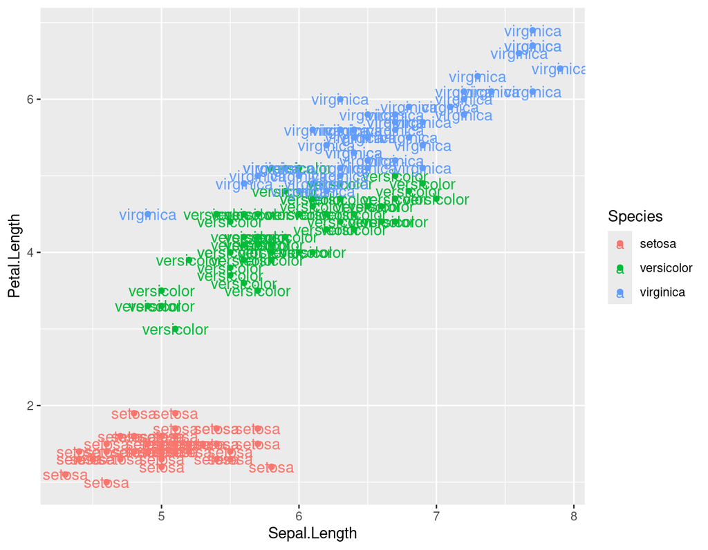

```r
p + geom_text(aes(label = Species))
```

También podíamos haber añadido el valor de la longitud del pétalo.

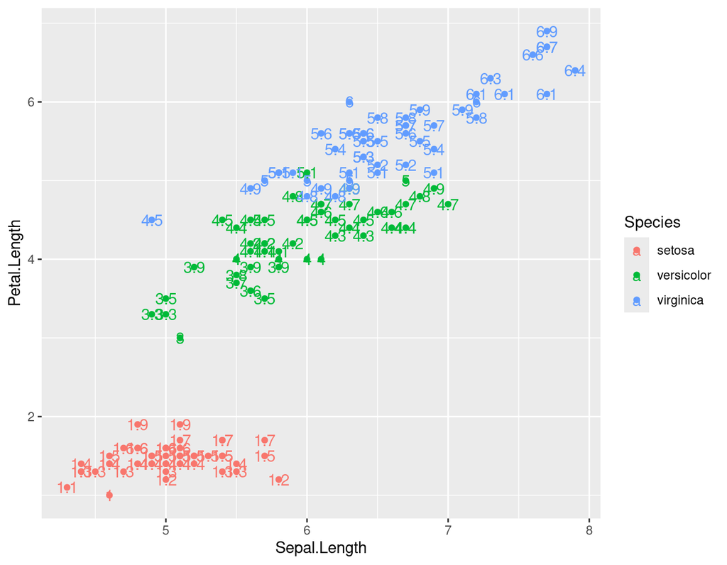

```r
p + geom_text(aes(label = Petal.Length))
```

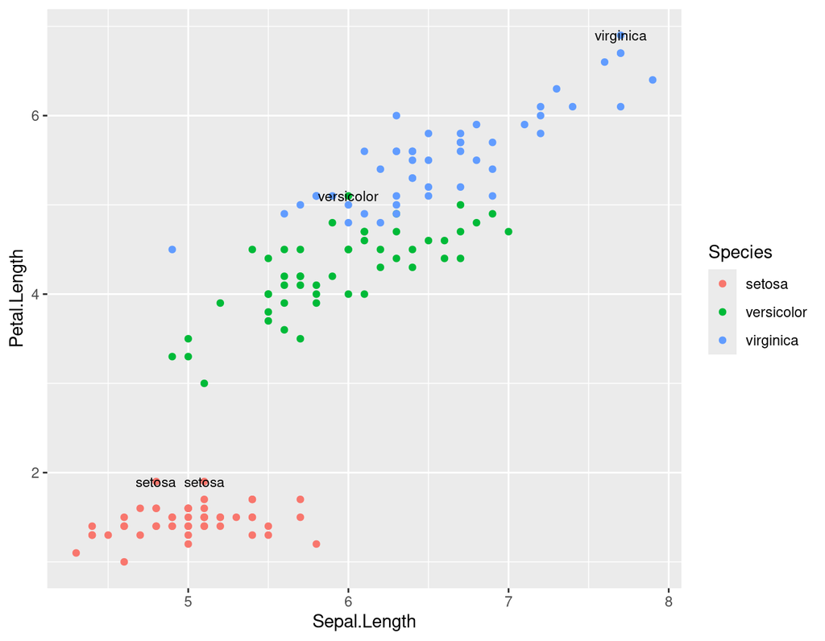

```r
#- seleccionamos los lirios más grandes de cada especie
iris_max <- iris %>% group_by(Species) %>% slice_max(Petal.Length, n = 1)

p +
 geom_text(data = iris_max, aes(label = Species), color = "black", size = 3)
```

Podemos ajustar la posición y tamaño del texto, etc.. Por ejemplo, podemos cambiar la alineación de las anotaciones con con `hjust(“left”, “center”, “right”, “inward”, “outward”)` y `vjust (“bottom”, “middle”, “top”, “inward”, “outward”)`.

#### Lineas

Podemos añadir lineas:

```r
p + geom_vline(xintercept = 6)
p + geom_hline(yintercept = 5, size = 1.7, colour = "purple", linetype = "dashed")
p + geom_abline(intercept = 0.7, slope = 0.4, size = 1.9, colour = "steelblue")
```